This notebook takes off from [Visualize Parts of Speech 1](https://jss367.github.io/Visualize-Parts-of-Speech-1/), which ended with a visualization from a single text. In this notebook we look at how to visually compare the part of speech usage in many texts.

```python
from urllib import request
import nltk
import os
import pandas as pd
import matplotlib
import matplotlib.pyplot as plt
```

This time we're going to make a class called books that will store the methods we need. Each book will have a title, a url (from Project Gutenberg), a word where the text actually starts, and a word where the text actually ends. We'll also want to hold the raw text, the tokens, and the parts of speech within the class. We'll build methods within the class to determine each of these.

```python
class Book(object):
    all_books = []
    def __init__(self, title, url, start=0, end=-1):
        # start is the location of where the book actually begins in the text file (skips headers, publisher info, etc.)
        # Let's create an end text so we can just grab a small amount for testing
        self.title = title
        self.url = url
        self.start = start
        self.end = end
        self.raw_ = None
        self.tokens_ = None
        self.pos_ = None

    def __str__(self):
        return self.title

    @property
    def raw(self):
        if self.raw_ is None:
            #First check if the file is stored locally
            fname = 'C:/Users/HMISYS/Google Drive/JupyterNotebooks/StyleStudio/corpora/canon_texts/' + self.title
            if os.path.isfile(fname) and os.stat(fname).st_size != 0:
                print("{title} file already exists".format(title=self.title))
                print("Extracting text from file")
                with open(fname, 'r') as f:
                    raw = f.read()
            else:
                print("{title} does not already exist. Grabbing from project Gutenberg".format(title=self.title))
                response = request.urlopen(self.url)
                raw = response.read().decode('utf-8-sig')
                print("Now let's save it")
                with open(fname, 'w') as outfile:
                    outfile.write(raw)
            self.raw_ = raw[self.start:self.end]
        return self.raw_

    @property
    def tokens(self):
        if self.tokens_ is None:
            self.tokens_ = nltk.word_tokenize(self.raw)
        return self.tokens_


    @property
    def pos(self):
        if self.pos_ == None:

            def mytagger(tokens):
                '''This function inputs tokens'''
                tags = nltk.pos_tag(tokens)
                return tags

            tagged = mytagger(self.tokens)

            # Note that IN can be either a preposition or a conjunction, for now we're going to list it with the prepositions
            common_noun_pos = ['NN', 'NNS']
            common_nouns = []
            verb_pos = ['VB', 'VBD', 'VBG', 'VBN', 'VBP', 'VBZ']
            verbs=[]
            adjective_pos = ['JJ', 'JJR', 'JJS']
            adjectives = []
            pronoun_pos = ['PRP', 'PRP$', 'WP', 'WP$']
            pronouns = []
            adverb_pos = ['RB', 'RBR', 'RBS', 'WRB']
            adverbs = []
            proper_noun_pos = ['NNP', 'NNPS']
            proper_nouns = []
            conjunction_pos = ['CC']
            conjunctions = []
            preposition_pos = ['IN', 'TO']
            prepositions = []
            interjection_pos = ['UH']
            interjections = []
            modal_pos = ['MD'] # But these are also verbs, so let's make sure they show up as such
            modals = []
            tagged_other_pos = ['CD', 'DT', 'EX', 'FW', 'LS', 'PDT', 'POS', 'RP', 'SYM', 'WDT']
            tagged_others = []
            other = []

            for idx, token in enumerate(tagged):
                if token[1] in common_noun_pos:
                    common_nouns.append(token)
                elif token[1] in verb_pos:
                    verbs.append(token)
                elif token[1] in adjective_pos:
                    adjectives.append(token)
                elif token[1] in pronoun_pos:
                    pronouns.append(token)
                elif token[1] in adverb_pos:
                    adverbs.append(token)
                elif token[1] in proper_noun_pos:
                    proper_nouns.append(token)
                elif token[1] in conjunction_pos:
                    conjunctions.append(token)
                elif token[1] in preposition_pos:
                    prepositions.append(token)
                elif token[1] in interjection_pos:
                    interjections.append(token)
                elif token[1] in modal_pos:
                    modals.append(token)
                elif token[1] in tagged_other_pos:
                    tagged_others.append(token)
                else:
                    other.append(token)


            self.pos_ = [common_nouns, verbs, adjectives, pronouns, adverbs, proper_nouns, conjunctions, prepositions, interjections, modals]
        return self.pos_
        # Append modals to verbs
        # Create nouns that is both proper nouns and common nouns
```

```python
books = [Book('Frankenstein', 'http://www.gutenberg.org/cache/epub/84/pg84.txt', 500),
        Book('Great Expectations', 'http://www.gutenberg.org/files/1400/1400-0.txt', 885),
        Book('A Tale of Two Cities', 'https://www.gutenberg.org/files/98/98-0.txt', 2400),
        Book('Pride and Prejudice', 'https://www.gutenberg.org/files/1342/1342-0.txt', 1200),
        Book("Alice's Adventures in Wonderland", 'https://www.gutenberg.org/files/11/11-0.txt', 1200),
        Book('Oliver Twist', 'http://www.gutenberg.org/cache/epub/730/pg730.txt', 500)]
```

```python
# We'll grab this function from the Part of Speech notebook
import matplotlib.pyplot as plt
def pos_plotter(parts_of_speech):
    '''This function inputs a specific list of lists that is shown in the Part of Speech notebook'''
    all_labels = ['common_nouns', 'verbs', 'adjectives', 'pronouns', 'adverbs', 'proper_nouns', 'conjunctions', 'prepositions', 'interjections', 'modals']
    pos_dict = dict(zip(all_labels, parts_of_speech))
    labels=[]
    data=[]
    for pos, lst in pos_dict.items():
        if lst:
            data.append(len(lst))
            labels.append(pos)
    fig1, ax1 = plt.subplots()
    ax1.pie(data, labels=labels)
    ax1.axis('equal')  # Equal aspect ratio ensures that pie is drawn as a circle.
    plt.show()
```

```python
titles = []
for book in books:
    titles.append(book.title)
print(titles)
```

```
['Frankenstein', 'Great Expectations', 'A Tale of Two Cities', 'Pride and Prejudice', "Alice's Adventures in Wonderland", 'Oliver Twist']
```

```
Frankenstein file already exists
Extracting text from file
```

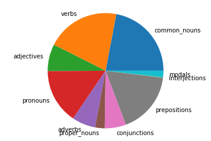

```
Great Expectations file already exists
Extracting text from file
```

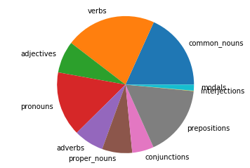

```
A Tale of Two Cities file already exists
Extracting text from file
```

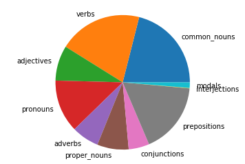

```
Pride and Prejudice file already exists
Extracting text from file
```

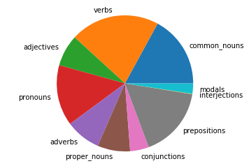

```
Alice's Adventures in Wonderland file already exists
Extracting text from file
```

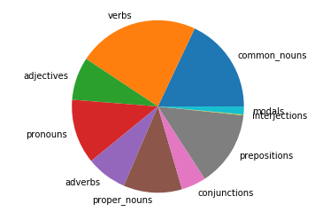

```
Oliver Twist file already exists
Extracting text from file
```

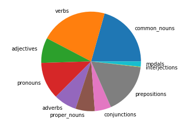

```python
for book in books:
    pos_plotter(book.pos)
```

It is not easy to compare the relative part of speech usage using pie charts. A better way would be to make a horizontal bar chart for each book and then stack them vertically to compare. Let's try that.

```python
# We'll grab this function from the Part of Speech notebook
import matplotlib.pyplot as plt
def pos_plotter2(parts_of_speech):
    '''This function inputs a specific list of lists that is shown in the Part of Speech notebook'''
    all_labels = ['common_nouns', 'verbs', 'adjectives', 'pronouns', 'adverbs', 'proper_nouns', 'conjunctions', 'prepositions', 'interjections', 'modals']
    pos_dict = dict(zip(all_labels, parts_of_speech))
    labels=[]
    data=[]
    for pos, lst in pos_dict.items():
        if lst:
            data.append(len(lst))
            labels.append(pos)
    fig1, ax1 = plt.subplots()
    ax1.bar(data, labels=labels)
    ax1.axis('equal')  # Equal aspect ratio ensures that pie is drawn as a circle.
    plt.show()
```

```python
nouns = []
verbs = []
adjectives = []
pronouns = []
adverbs = []
conjunctions = []
prepositions = []
interjections = []
modals = []
for book in books:
    nouns.append(len(book.pos[0]) + len(book.pos[5])) # common + proper
    verbs.append(len(book.pos[1]) + len(book.pos[9])) # verbs + modals
    adjectives.append(len(book.pos[2]))
    pronouns.append(len(book.pos[3]))
    adverbs.append(len(book.pos[4]))
    conjunctions.append(len(book.pos[6]))
    prepositions.append(len(book.pos[7]))
    interjections.append(len(book.pos[8]))
```

```python
# Now let's put everything in a pandas dataframe
df = pd.DataFrame({'nouns': nouns, 'verbs': verbs, 'adjectives': adjectives, 'pronouns': pronouns, 'adverbs': adverbs,
                   'conjunctions': conjunctions, 'prepositions': prepositions, 'interjections': interjections})
```

```python
df_norm = df.div(df.sum(axis=1), axis='index')
df_norm.head()
```

|  | adjectives | adverbs | conjunctions | interjections | nouns | prepositions | pronouns | verbs |
| --- | --- | --- | --- | --- | --- | --- | --- | --- |
| 0 | 0.075583 | 0.065945 | 0.059307 | 0.000812 | 0.246895 | 0.173428 | 0.153978 | 0.224053 |
| 1 | 0.075306 | 0.070654 | 0.051152 | 0.000970 | 0.253452 | 0.167824 | 0.152590 | 0.228051 |
| 2 | 0.084404 | 0.065936 | 0.049740 | 0.001059 | 0.286252 | 0.171419 | 0.126895 | 0.214297 |
| 3 | 0.075008 | 0.083417 | 0.044391 | 0.000983 | 0.248063 | 0.167859 | 0.144574 | 0.235704 |
| 4 | 0.080615 | 0.076214 | 0.046409 | 0.001547 | 0.289938 | 0.141806 | 0.121420 | 0.242050 |

We'll need a function that will help convert the axes to percentages. Let's make that now.

```python
def to_percent(y, position):
    # Ignore the passed in position. This has the effect of scaling the default
    # tick locations.
    s = str(100 * y)

    # The percent symbol needs escaping in latex
    if matplotlib.rcParams['text.usetex'] is True:
        return s + r'$\%$'
    else:
        return s + '%'
```

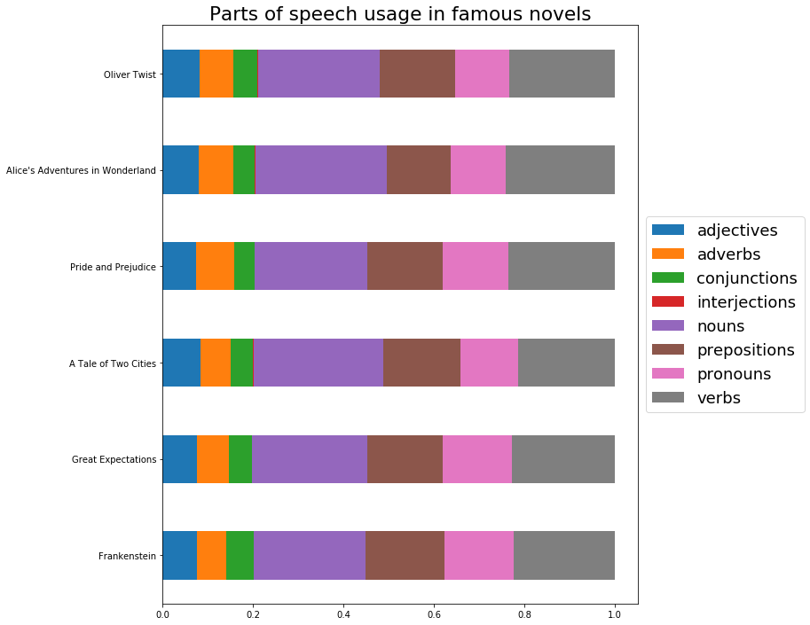

```python
fig, ax = plt.subplots()
fig.set_size_inches(12,12)
matplotlib.rcParams.update({'font.size': 18})

df_norm.plot.barh(stacked=True, ax=ax);

ax.set_title("Parts of speech usage in famous novels")
#ax.legend(loc='upper left')


# Shrink current axis by 20%
box = ax.get_position()
ax.set_position([box.x0, box.y0, box.width * 0.8, box.height])

# Add book titles
ax.set_yticklabels(titles, minor=False)
# Put a legend to the right of the current axis
ax.legend(loc='center left', bbox_to_anchor=(1, 0.5))

plt.show()
```